# Plotting with ggplot2

Institut für Organisation und Globale Managementstudien, JKU Linz

## What is ggplot2?

- An implementation of *The Grammar of Graphics* by Leland Wilkinson
- Written by Hadley Wickham (while he was a graduate student at Iowa State)
- A “third” graphics system for R (along with **base** and **lattice**)
- Available from CRAN via `install.packages()`
- Web site: http://ggplot2.org (better documentation)

## What is ggplot2?

- Grammar of graphics represents an abstraction of graphics ideas/objects
- Think “verb”, “noun”, “adjective” for graphics
- Allows for a “theory” of graphics on which to build new graphics and graphics objects
- “Shorten the distance from mind to page”

## Basic Components of a ggplot2 Plot

- A *data frame*
- *aesthetic mappings*: how variables are mapped to axes, color, size
- *geoms*: geometric objects like points, lines, shapes.
- *facets*: for conditional plots.
- *stats*: statistical transformations like binning, quantiles, smoothing.
- *scales*: what scale an aesthetic map uses (example: male = red, female = blue).
- *coordinate system*

## Example Dataset

```r
library(ggplot2)
str(mpg)
```

```
## Classes 'tbl_df', 'tbl' and 'data.frame':    234 obs. of  11 variables:
##  $ manufacturer: chr  "audi" "audi" "audi" "audi" ...
##  $ model       : chr  "a4" "a4" "a4" "a4" ...
##  $ displ       : num  1.8 1.8 2 2 2.8 2.8 3.1 1.8 1.8 2 ...
##  $ year        : int  1999 1999 2008 2008 1999 1999 2008 1999 1999 2008 ...
##  $ cyl         : int  4 4 4 4 6 6 6 4 4 4 ...
##  $ trans       : chr  "auto(l5)" "manual(m5)" "manual(m6)" "auto(av)" ...
##  $ drv         : chr  "f" "f" "f" "f" ...
##  $ cty         : int  18 21 20 21 16 18 18 18 16 20 ...
##  $ hwy         : int  29 29 31 30 26 26 27 26 25 28 ...
##  $ fl          : chr  "p" "p" "p" "p" ...
##  $ class       : chr  "compact" "compact" "compact" "compact" ...
```

## Not Quite a Plot Yet

### Mapping of data and variables to axes

```r
g  <- ggplot(data = mpg, aes(displ, hwy))
summary(g)
```

```
## data: manufacturer, model, displ, year, cyl, trans, drv, cty, hwy,
##   fl, class [234x11]
## mapping:  x = displ, y = hwy
## faceting: facet_null()
```

## Basic Plot with Point Layer

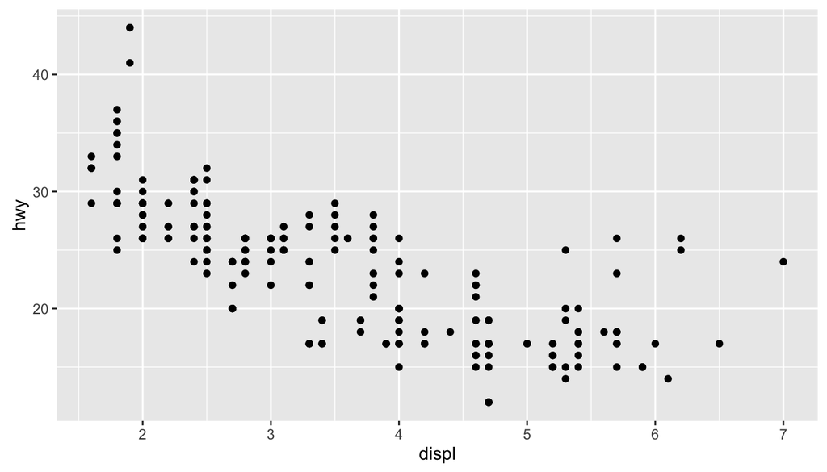

```r
g  <- ggplot(data = mpg, aes(displ, hwy)) +
  geom_point()
g
```

## Color-Code Third Variable

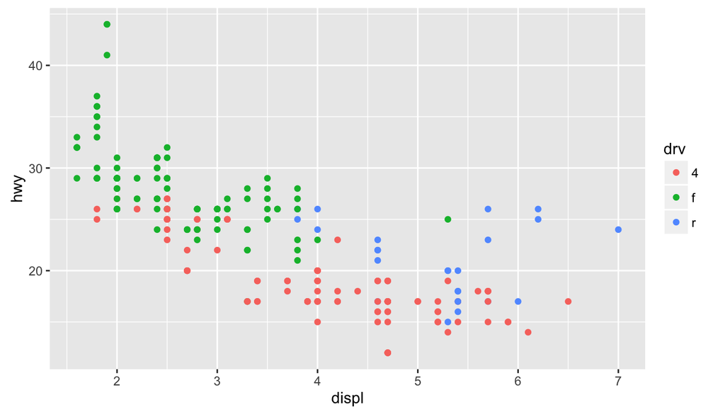

```r
h  <- ggplot(data = mpg, aes(displ, hwy, color = drv)) +
  geom_point()
h
```

## Adding a Layer: Facets

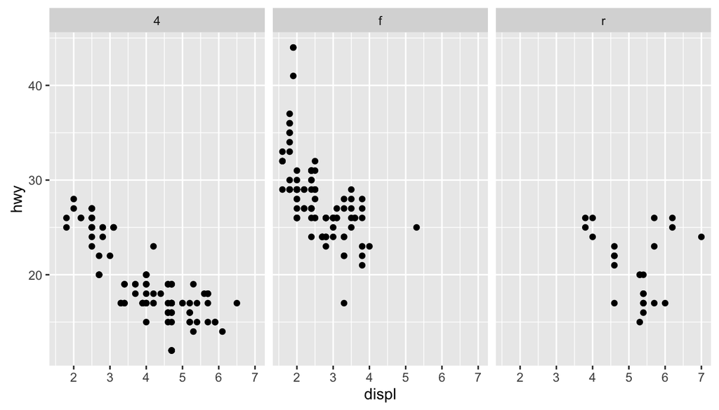

```r
g  <- ggplot(data = mpg, aes(displ, hwy)) +
  geom_point()
g  <- g + facet_grid(facets = . ~ drv)
g
```

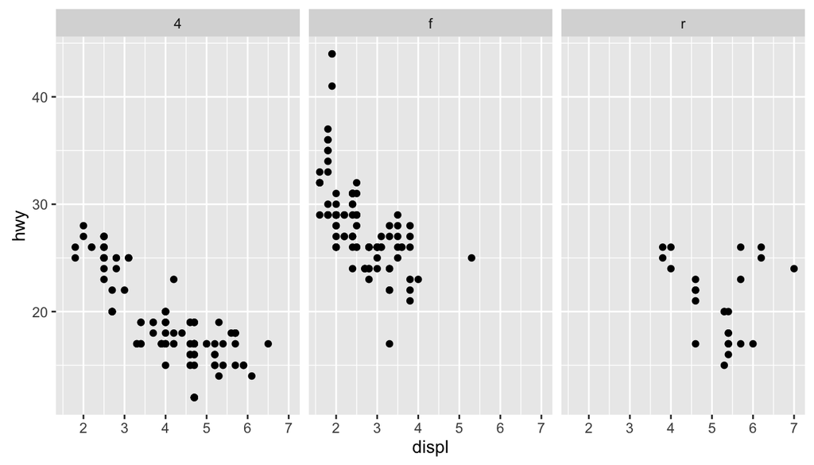

```r
levels(mpg$drv) <- c("4-weel-drive", "front-wheel-drive", "rear-wheel-drive")
g  <- ggplot(data = mpg, aes(displ, hwy)) +
             geom_point() +
             facet_grid(facets = . ~ drv)
g
```

## Adding Another Layer: Regression Lines

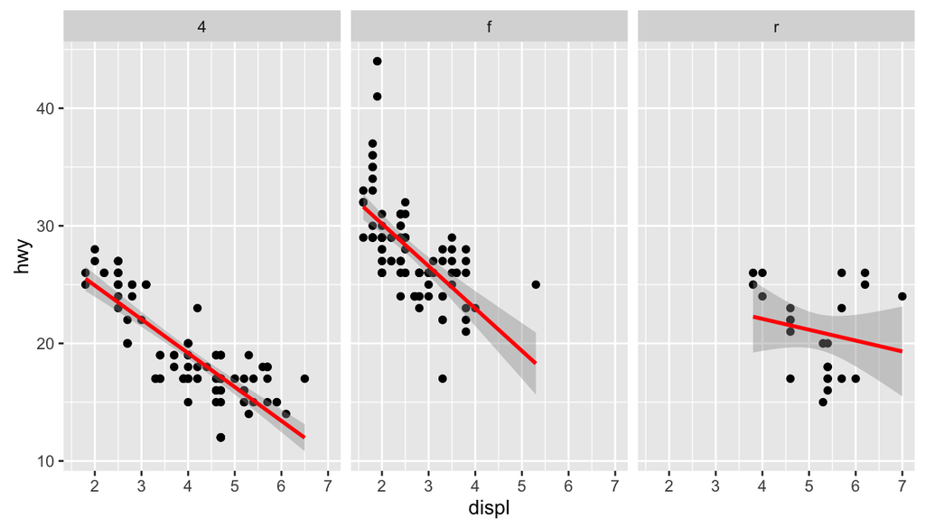

```r
g  <- g + geom_smooth(method = "lm", se = T, color = "red")
g
```

## Annotation

- Labels: `xlab()`, `ylab()`, `labs()`, `ggtitle()`
- Each of the "geom"" functions has options to modify
- For things that only make sense globally, use `theme()`
- Example: `theme(legend.position = "none")`
- Two standard appearance themes are included
- `theme_gray()`: The default theme (gray background)
- `theme_bw()`: More stark/plain

## Another Layer: Title and Axes Lables

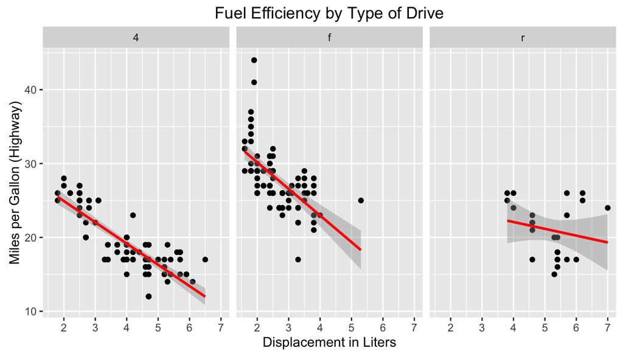

```r
g <- g + labs(y = "Miles per Gallon (Highway)",
              x = "Displacement in Liters",
              title = "Fuel Efficiency by Type of Drive")
g
```

## Changing Fonts and Backgrounds

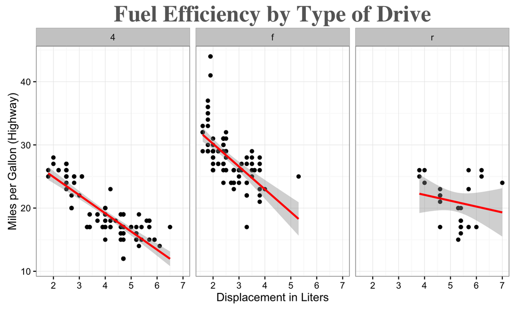

```r
g <- g + theme_bw() +
  theme(plot.title = element_text(family = "Times",
                                  color="#666666",
                                  face="bold", size=24, vjust=2))
g
```

## Final Plot

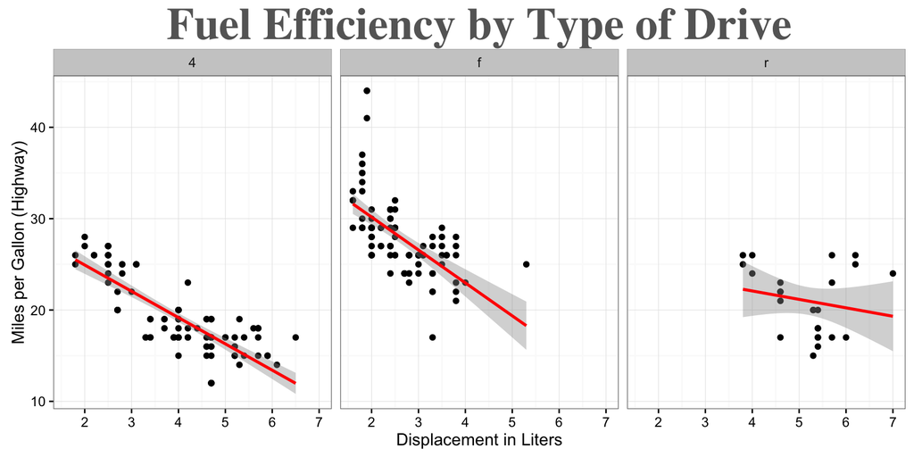

## Code Final Plot

```r
levels(mpg$drv) <- c("4-weel-drive", "front-wheel-drive", "rear-wheel-drive")
ggplot(data = mpg, aes(displ, hwy)) +
  geom_point() +
  facet_grid(facets = . ~ drv) +
  geom_smooth(method = "lm", se = T, color = "red") +
  labs(y = "Miles per Gallon (Highway)",
       x = "Displacement in Liters",
       title = "Fuel Efficiency by Type of Drive") +
  theme_bw() +
  theme(plot.title = element_text(family = "Times", color="#666666",
                                  face="bold", size=32, vjust=2))
```

## Printing Plots

```r
ggsave("/Users/pp/Desktop/fuel.pdf", g, width=6, height=4)
```

Note: File extension drives file format.

## Summary

- ggplot2 is very powerful and flexible if you learn the “grammar” and the various elements that can be tuned/modified
- Many more types of plots can be made; explore and play around with the package

## Resources

- The *ggplot2* book by Hadley Wickham
- The *R Graphics Cookbook* by Winston Chang (examples in base plots and in ggplot2)
- ggplot2 web site (http://ggplot2.org)